# Data preprocessing

Authors

Louisa Diallo

Fabian Arntz

Published

April 8, 2026

# 1 libraries and data

```r
suppressWarnings(suppressMessages(library(tidyverse)))
suppressWarnings(suppressMessages(library(patchwork)))
suppressWarnings(suppressMessages(library(readxl)))
suppressWarnings(suppressMessages(library(lme4)))
suppressWarnings(suppressMessages(library(gt)))

cbPalette <- c( "#0072B2", "#D55E00", "#009E73", "#CC79A7",
                "#F0E442", "#56B4E9", "#999999", "#E69F00")

m_sd <- function(x,y){paste0(round(mean(x, na.rm = y),1), " ± ", round(sd(x, na.rm = y),1))}

berlin_hd <- as.Date(c(
  "2023-12-25",
  "2023-12-26",
  "2024-01-01",
  "2024-12-25",
  "2024-12-26",
  "2025-01-01"
))

load_rda <- function(x) {
  load(x)
  return(dat.subj)}

data <- read_delim("../../../06_fp2_wp3/01_can_preprocessing/data/raw/redcap_1013_20250225.csv", delim = ";", escape_double = FALSE, trim_ws = TRUE)  |>
  mutate(Subj = paste0("S", participant_id),
         leg = ifelse(redcap_event_name == "event_1_arm_1", "pre", "post")) |>
  relocate(Subj, leg)

id <- suppressMessages(read_excel("../../../06_fp2_wp3/01_can_preprocessing/data/raw/Charite_data_202401291325.xlsx")) |>
  select(Subj = ID, contains("mov")) |>
  pivot_longer(contains("mov"), values_to = "mov", names_to = NULL) |>
  filter(!is.na(mov)) |>
  mutate(Subj = paste0("S", str_pad(Subj, 5, "left", 0)),
         mov = paste0("S", str_pad(mov, 3, "left", 0))) |>
  rbind(
    read_excel("../../../06_fp2_wp3/01_can_preprocessing/data/raw/charite_verlaufliste_20250218.xlsx") |>
      select(Subj = ID, contains("MS ")) |>
      pivot_longer(contains("MS "), values_to = "mov", names_to = NULL) |>
      filter(!is.na(mov)) |>
      mutate(Subj = paste0("S", substr(Subj, 2,6)),
             mov = paste0("S", str_pad(mov, 3, "left", 0)))) |>
  unique()

load("../../../06_fp2_wp3/01_can_preprocessing/data/preprocessed/rda/can.rda")

can <- dat.can |>
  mutate(Subj = paste0("S", substr(ID_red, 2,6)),
         leg = ifelse(date < as_date("2024-04-01"), "pre", "post")) |>
  select(Subj, leg, date = date_ref, can_b, can_g) |>
  mutate(can_b = ifelse(can_g == 0, 0, can_b)) |>
  arrange(Subj, date)

load("../../../06_fp2_wp3/01_can_preprocessing/data/preprocessed/rda/set.rda")

set <- dat.set |>
  mutate(Subj = paste0("S", substr(ID_red, 2,6)),
         leg = ifelse(date < "2024-04-01", "pre", "post")) |>
  select(Subj, leg, date = date_ref,
         public_outdoors = public_outside,
         public_indoors = public_inside,
         private_outdoors = private_outside,
         private_indoors = private_inside,
         alone, twopeople, smallgroup, largegroup)

cohort <- load_rda("../../../01_service/02_cohort_preprocessing/data/rda/subj.rda")
```

# 2 cohort assessments

```r
dat.subj_FA <- data |>
  select(Subj, leg, auditc = bx_athome_auditc_sum, aud = bx_aud_sum,
         cudit = bx_cuditq_sum, gender = bx_sozio_gender, birthday = screen_birthday) |>
  group_by(Subj) |>
  fill(birthday, .direction = "down") |>
  mutate(age = as.numeric(as_date("2023-11-27") - as_date(birthday))/365.25,
         gender = case_when(gender == 1 ~ "man",
                            gender == 2 ~ "woman",
                            gender == 3 ~ "diverse"),
         gender = case_when(Subj %in% Subj_na_gender ~ "man", # manual corrections for 5 IDs
                            TRUE ~ gender),
         incl = ifelse(Subj %in% can$Subj, "incl", "excl"),
         enroll = ifelse(incl == "excl" | Subj %in% Subj_excl, "no", "enroll"), # manual corrections for 3 IDs
         cohort = ifelse(Subj %in% cohort$Subj, "SFB cohort", "newly recruited")) |>
  select(Subj, leg, incl, enroll, cohort, gender, age, auditc, aud, cudit)
```

## 2.1 baseline descriptives

### 2.1.1 recruitment: phone screenings

Number of Subjects during study recruitment and enrolment

- pre legalisation phone screening: 78
- pre legalisation study inclusion: 61
- pre legalisation EMA enrollment: 61
- post legalisation phone screening: 52

Recruitment source:

```r
dat.subj_FA |> filter(leg == "pre" & enroll == "enroll") |> group_by(cohort) |> reframe(n = n()) |> gt()
```

| cohort | n |
| --- | --- |
| SFB cohort | 31 |
| newly recruited | 30 |

Gender distribution during enrolment

```r
dat.subj_FA |>
  group_by(leg, incl, enroll) |>
  reframe(n = n(),
          `w/m/d/na` = paste0(sum(gender == "woman", na.rm = T), "|",sum(gender == "man", na.rm = T),"|", sum(gender == "diverse", na.rm = T), "|", sum(is.na(gender)))) |>
  gt()
```

| leg | incl | enroll | n | w/m/d/na |
| --- | --- | --- | --- | --- |
| post | incl | enroll | 52 | 17\|32\|2\|1 |
| pre | excl | no | 17 | 1\|3\|0\|13 |
| pre | incl | enroll | 61 | 21\|38\|2\|0 |

Age, aud, audit, cudit at baseline

```r
dat.subj_FA |>
  filter(enroll == "enroll") |>
  pivot_longer(c(age, aud, auditc, cudit)) |>
  mutate(cohort = tolower(substr(cohort,1,3))) |>
  group_by(cohort, leg, name) |>
  reframe(n = n(),
          missing = sum(is.na(value)),
          value = m_sd(value, TRUE)) |>
  pivot_wider(names_from = cohort, values_from = c(n, missing, value)) |>
  select(leg, name, contains("sfb"), contains("new")) |>
  gt()
```

| leg | name | n_sfb | missing_sfb | value_sfb | n_new | missing_new | value_new |
| --- | --- | --- | --- | --- | --- | --- | --- |
| post | age | 30 | 0 | 35.8 ± 12.8 | 22 | 1 | 30.7 ± 6.1 |
| post | aud | 30 | 0 | 0.5 ± 0.8 | 22 | 0 | 0.2 ± 0.7 |
| post | auditc | 30 | 0 | 5.2 ± 2.4 | 22 | 1 | 4.1 ± 2.3 |
| post | cudit | 30 | 0 | 8.5 ± 7.1 | 22 | 1 | 9.9 ± 7 |
| pre | age | 31 | 0 | 35.6 ± 12.7 | 30 | 1 | 30.4 ± 6.4 |
| pre | aud | 31 | 0 | 1.6 ± 2.2 | 30 | 1 | 0.4 ± 0.6 |
| pre | auditc | 31 | 0 | 5.7 ± 2.4 | 30 | 0 | 3.8 ± 2.3 |
| pre | cudit | 31 | 0 | 8.8 ± 7.1 | 30 | 0 | 11 ± 6.4 |

# 3 ema assessments

## 3.1 cannabis distribution

Boxcox analysis of cannabis amounts on consumption days

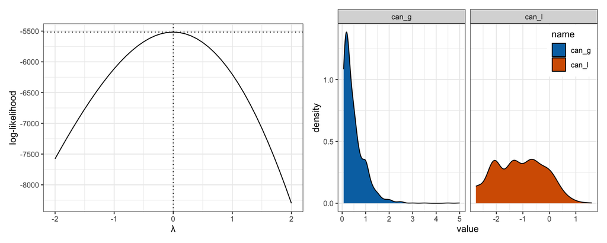

```r
bxcx <- MASS::boxcox(lm(can_g ~ 1, data = can |> filter(can_b == 1)), plotit = FALSE)

p_bxcx <- tibble(x = bxcx$x, y = bxcx$y) |>
  ggplot(aes(x = x, y = y)) +
  geom_line() +
  geom_hline(aes(yintercept = max(bxcx$y)), linetype = "dotted") +
  geom_vline(aes(xintercept = bxcx$x[bxcx$y == max(bxcx$y)]), linetype = "dotted") +
  labs(y = "log-likelihood", x = "λ") +
  theme_bw()

p_candist <- can |>
  filter(can_b == 1) |>
  mutate(can_l = log(can_g)) |>
  pivot_longer(c(can_g, can_l)) |>
  ggplot(aes(x = value, group = name, fill = name)) +
  geom_density(adjust = 1.4) +
  facet_grid(.~name, scale = "free_x") +
  theme_bw() +
  theme(legend.position = "inside",
        legend.position.inside = c(.99,.99),
        legend.justification.inside = c(.99,.99)) +
  scale_fill_manual(values = cbPalette)

p_bxcx + p_candist
```

## 3.2 setting

### 3.2.1 correlations

Consumption setting were assessed as

- public AND/OR private
- outside AND/OR inside
- alone AND/OR twopeople AND/OR smallgroup AND/OR largegroup

with multiple answers possible

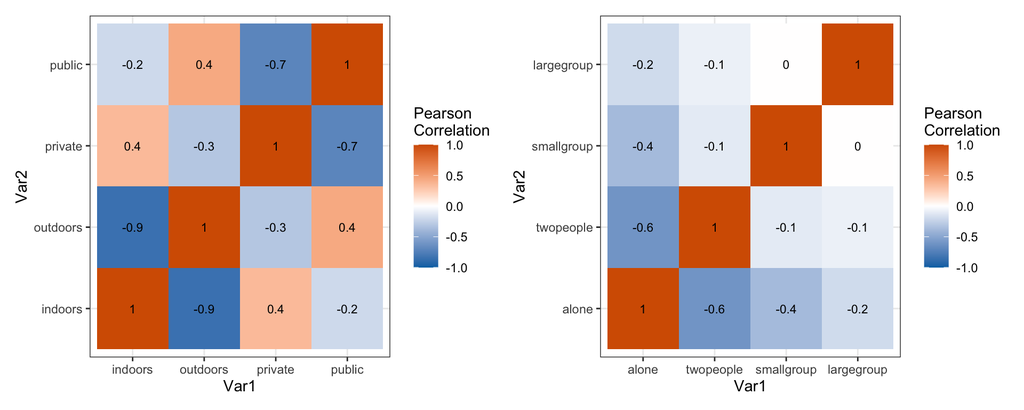

```r
p_set_loc_cor <- set |>
  group_by(Subj, date) |>
  mutate(
    indoors  = max(c(private_indoors, public_indoors)),
    outdoors = max(c(private_outdoors, public_outdoors)),
    private = max(c(private_indoors, private_outdoors)),
    public  = max(c(public_indoors, public_outdoors))
  ) |>
  ungroup() |>
  select(indoors, outdoors, private, public) |>
  cor(use = "pairwise.complete.obs") |>
  reshape2::melt() |>
  mutate(test0 = ifelse(substr(Var1,1,3)=="neo",1,2),
    test1 = ifelse(substr(Var2,1,3)=="neo",1,2)) |>
  ggplot(aes(x=Var1, y=Var2, fill=value)) +
  geom_tile() +
  geom_text(aes(label = round(value,1)), size = 3) +
  theme(axis.text.x = element_text(angle = 90, vjust = 0.5, hjust=1)) +
  scale_fill_gradient2(low = cbPalette[1], high = cbPalette[2],
   midpoint = 0, limit = c(-1,1), space = "Lab",
   name="Pearson\nCorrelation") +
  theme_bw() +
  theme()

p_set_group_cor <- dat.set |>
  select(alone, twopeople, smallgroup, largegroup) |>
  cor(use = "pairwise.complete.obs") |>
  reshape2::melt() |>
  mutate(test0 = ifelse(substr(Var1,1,3)=="neo",1,2),
    test1 = ifelse(substr(Var2,1,3)=="neo",1,2)) |>
  ggplot(aes(x=Var1, y=Var2, fill=value)) +
  geom_tile() +
  geom_text(aes(label = round(value,1)), size = 3) +
  theme(axis.text.x = element_text(angle = 90, vjust = 0.5, hjust=1)) +
  scale_fill_gradient2(low = cbPalette[1], high = cbPalette[2],
   midpoint = 0, limit = c(-1,1), space = "Lab",
   name="Pearson\nCorrelation") +
  theme_bw() +
  theme()

p_set_loc_cor + p_set_group_cor
```

As consumption occured on days inside AND outside etc true binaries were derived:

- `set_b` ~ days with/out public consumption
- `loc_b` ~ days with/out outdoor consumption
- `group_b` ~ days with/out only alone consumption

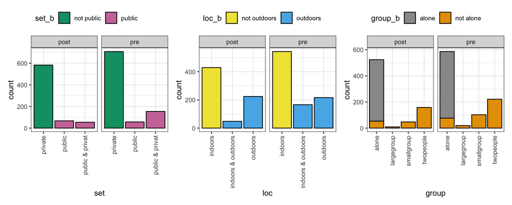

```r
p_pub_dist <- set |>
  select(Subj, leg, date, starts_with("p")) |>
  pivot_longer(4:7, names_to = c("set","loc"), names_sep = "_") |>
  group_by(Subj,leg, date, set) |>
  reframe(value = max(value)) |>
  group_by(Subj, leg, date) |>
  mutate(sum = sum(value)) |>
  filter(value !=0) |>
  reframe(set = ifelse(sum == 2, "public & privat", set),
          set_b = ifelse(set == "private", "not public", "public")) |>
  ggplot(aes(x = set, fill = set_b)) +
  geom_bar(stat = "count", colour = "black") +
  facet_grid(.~leg) +
  theme_bw() +
  theme(legend.position = "top",
        legend.justification.top = c(.01,.01),
        axis.text.x = element_text(angle = 90, vjust = 0.5, hjust=1)) +
  scale_fill_manual(values = cbPalette[3:4])

p_door_dist <- set |>
  select(Subj, leg, date, starts_with("p")) |>
  pivot_longer(4:7, names_to = c("set","loc"), names_sep = "_") |>
  group_by(Subj,leg, date, loc) |>
  reframe(value = max(value)) |>
  group_by(Subj, leg, date) |>
  mutate(sum = sum(value)) |>
  filter(value !=0) |>
  reframe(loc = ifelse(sum == 2, "indoors & outdoors", loc),
          loc_b = ifelse(loc == "indoors", "not outdoors", "outdoors")) |>
  ggplot(aes(x = loc, fill = loc_b)) +
  geom_bar(stat = "count", colour = "black") +
  facet_grid(.~leg) +
  theme_bw() +
  theme(legend.position = "top",
        legend.justification.top = c(.01,.01),
        axis.text.x = element_text(angle = 90, vjust = 0.5, hjust=1)) +
  scale_fill_manual(values = cbPalette[5:6])

p_group_dist <- set |>
  select(Subj, leg, date, alone, twopeople, smallgroup, largegroup) |>
  pivot_longer(4:7, names_to = "group") |>
  group_by(Subj,leg, date, group) |>
  reframe(value = max(value)) |>
  group_by(Subj, leg, date) |>
  mutate(sum = sum(value)) |>
  filter(value !=0) |>
  reframe(group = group,
          group_b = ifelse(group == "alone" & sum == 1, "alone", "not alone"),) |>
  ggplot(aes(x = group, fill = group_b)) +
  geom_bar(stat = "count", colour = "black") +
  facet_grid(.~leg) +
  theme_bw() +
  theme(legend.position = "top",
        legend.justification.top = c(.01,.01),
        axis.text.x = element_text(angle = 90, vjust = 0.5, hjust=1)) +
  scale_fill_manual(values = cbPalette[7:8])

p_pub_dist + p_door_dist + p_group_dist
```

```r
set2 <- set |>
  group_by(Subj, date) |>
  mutate(
    loc_b = factor(
      ifelse(max(c(private_outdoors, public_outdoors)) == 1, "outdoors", "not outdoors"),
      levels = c("not outdoors", "outdoors")
    ),
    set_b = factor(
      ifelse(max(c(public_indoors, public_outdoors)) == 1, "public", "not public"),
      levels = c("not public", "public")
    ),
    group_b = factor(
      ifelse(max(c(twopeople, smallgroup, largegroup)) == 1, "group", "not group"),
      levels = c("not group", "group")
    )
  ) |>
  ungroup() |>
  select(Subj, date, loc_b, set_b, group_b)
```

# 4 Models preprocessing

## 4.1 data preparation

Additional variables

- `leg` ~ dates pre/post legalisation
- `gender2` ~ true binary gender (woman/non-woman)
- `a1` ~ age centerd at 33.33
- `can_l` ~ log transformed cannabis amounts
- `weekday` ~ day of the week
- `wd` ~ weekday binary (we = friday:saturday vs wd = sunday:thursday)
- `hd` ~ holiday binary (holiday, non holiday)
- `month` ~ month
- `jd` ~ end of the year vs start of the year

```r
Data <- dat.subj_FA |>
  select(Subj,leg,gender,age) |>
  mutate(gender2 = ifelse(gender == "woman", gender, "non-woman")) |>
  group_by(Subj) |>
  mutate(leg_drop = factor(ifelse(n() == 1 | Subj %in% Subj_excl_post, "pre only", "pre/post"))) |> # manual corrections for 3 IDs
  right_join(can) |>
  filter(leg_drop == "pre/post")  |>
  ungroup() |>
  mutate(
    Subj = factor(Subj),
    leg = factor(leg, levels = c("pre", "post")),
    gender2 = factor(gender2, levels = c("woman","non-woman")),
    a1 = scale(age, scale = FALSE)[,1],
    can_l = case_when(can_b == 1 ~log(can_g), TRUE ~ NA),
    weekday = weekdays(date),
    wd = factor(ifelse(weekday %in% c("Friday", "Saturday"), "wd1", "wd0"),
                levels = c("wd0", "wd1")),
    hd = factor(ifelse(date %in% berlin_hd, "hd1", "hd0"),
                levels = c("hd0", "hd1")),
    month = months(date),
    jd = factor(ifelse(month %in% c("November", "December"), "end of year", "start of year"),
                levels = c("end of year", "start of year"))) |>
  arrange(Subj, date) |>
  left_join(set2)

save(file = "data/Data.rda", Data)
save(file = "data/subj.rda", dat.subj_FA)
```